# Days Away From Work

STAT 330 Portfolio Project Proposal

Author

Emma Messenger, Matthew Davis and Salinda Tanner

**Group members:** Emma Messenger, Matthew Davis, Salinda Tanner

## Question and audience

**State one focused regression question. Identify the intended audience, explain why the answer matters, and name the response and important candidate predictors.**

**Question:**

How can we predict an employees Days Away from their job based on an injury?

**Audience:**

This is important to insurance companies and employers because if we can know how many days an employee is out the employer knows how much insurance to get, and an insurer can know how much to charge (based on Days Away).

## Data

**Provide a working source link or citation. Describe the observational unit, dimensions, response, candidate predictors, collection process if known, and evidence that the data can answer your question. Address permission to share or retrieve the data and any privacy, representation, measurement, or ethical concern.**

```r
# Load packages and read the data with a relative path or reproducible step.
# Show only a compact check of dimensions and variables.
library(tidyverse)

filtered_path <- "ITA_Case_Data_Filter.csv"
full_path <- "ITA_Case_Detail_Data_2025_through_08-31-2026.csv"

if (file.exists(full_path)) {
  # Load original dataset
  data <- read.csv(full_path)

  # Filter rows and select columns
  data <- data[
      (is.na(data$date_of_death) | data$date_of_death == "") &
      data$incident_outcome != 1 &
      data$dafw_num_away >= 0 &
      data$djtr_num_tr >= 0,
    c(
      "establishment_ID",
      "state",
      "establishment_type",
      "Size",
      "total_hours_worked",
      "incident_outcome",
      "dafw_num_away",
      "djtr_num_tr",
      "type_of_incident",
      "incident_outcome"
    )
  ]

  # Randomly sample 60% of rows
  set.seed(123)

  data <- data[
    sample(nrow(data), size = floor(nrow(data) * 0.60)),
  ]

  # Save filtered dataset
  write.csv(data, filtered_path, row.names = FALSE)

} else {
  # Load previously filtered data
  data <- read.csv(filtered_path)
}

glimpse(data)
```

```
Rows: 466,996
Columns: 10
$ establishment_ID   <int> 1062686, 1035823, 74483, 1394964, 1116572, 1473696,…
$ state              <chr> "CA", "VA", "VA", "FL", "NJ", "OH", "TX", "AZ", "CA…
$ establishment_type <int> 1, 1, 1, 1, 1, 1, 1, 1, 1, 1, 1, 1, 1, 1, 1, 1, 1, …
$ Size               <int> 3, 22, 3, 3, 3, 3, 3, 22, 3, 3, 22, 21, 22, 3, 22, …
$ total_hours_worked <dbl> 474946, 310226, 2836971, 682445, 28828331, 6349294,…
$ incident_outcome   <int> 2, 2, 4, 4, 3, 4, 3, 2, 3, 4, 2, 2, 2, 4, 4, 2, 3, …
$ dafw_num_away      <int> 158, 56, 0, 0, 0, 0, 0, 20, 0, 0, 28, 123, 1, 0, 0,…
$ djtr_num_tr        <int> 0, 19, 0, 0, 7, 0, 80, 98, 4, 0, 24, 57, 0, 0, 0, 0…
$ type_of_incident   <int> 1, 1, 1, 1, 1, 1, 1, 1, 6, 1, 1, 1, 1, 1, 1, 1, 1, …
$ incident_outcome.1 <int> 2, 2, 4, 4, 3, 4, 3, 2, 3, 4, 2, 2, 2, 4, 4, 2, 3, …
```

Data Source:

> Occupational Safety and Health Administration. (2026). 2025 case detail summary data [Data set]. U.S. Department of Labor. https://www.osha.gov/sites/default/largefiles/ITA_Case_Detail_Data_2025_through_08-31-2026.csv

There are two potential response variables. Either the number of days away from work due to an injury `dafw_num_away` or the number of days transfered or restricted from work `djtr_num_away`.

The candidate predictors are: - State (state where the company is located) - Establishment Type (State Government, Local Government, or Private) - Size (Categorical) - Average Number of Employees (Numeric) - Total Hours Worked (Total number of hours worked in company)

I believe this data can answer our question under the assumption that they are correlated.

This is public data supplied by the Government. Our biggest ethical concern is how we display the company names, we would not want to poorly represent a company based on their injury reports.

## One useful first look

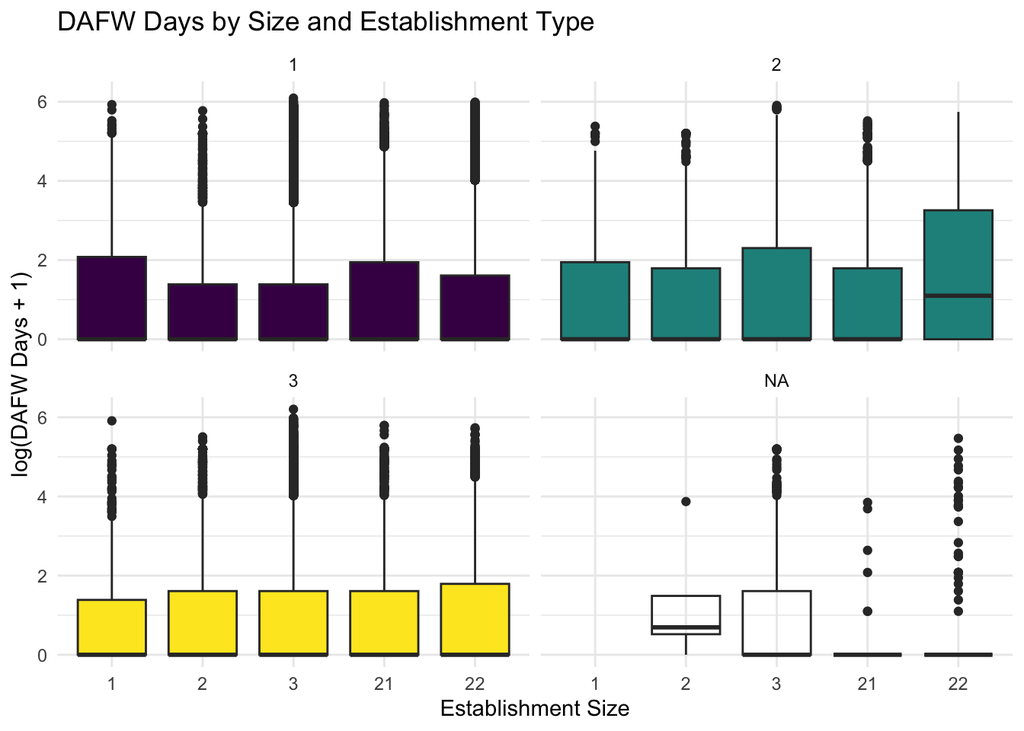

```r
# Create one figure that directly informs your research question.
# Include a useful title, labels, units, and accessible colors.
library(ggplot2)
library(viridis)

ggplot(
  data,
  aes(
    x = factor(Size),
    y = log1p(dafw_num_away),
    fill = factor(establishment_type)
  )
) +
  geom_boxplot() +
  facet_wrap(~ establishment_type) +
  scale_fill_viridis_d(option = "D") +
  labs(
    title = "DAFW Days by Size and Establishment Type",
    x = "Establishment Size",
    y = "log(DAFW Days + 1)",
    fill = "Establishment Type"
  ) +
  theme_minimal() +
  theme(
    legend.position = "none"
  )
```

## Baseline model

**Name and justify one simple starting model.** We will use a multiple linear regression model to analyze the relationship between total days away from work, establishment size, and establishment type. We will be able to determine whether larger establishments report more days away from work in relation to size of company. We selected this model because our primary analysis showed potential relationships between both predictors and the response.

```r
baseline_model <- lm(
  log1p(dafw_num_away) ~ factor(Size) + factor(establishment_type),
  data = data
)

summary(baseline_model)
```

```
Call:
lm(formula = log1p(dafw_num_away) ~ factor(Size) + factor(establishment_type),
    data = data)

Residuals:
    Min      1Q  Median      3Q     Max
-1.5207 -0.8604 -0.8604  0.5259  5.2666

Coefficients:
                            Estimate Std. Error t value Pr(>|t|)
(Intercept)                  1.11622    0.02804  39.811  < 2e-16 ***
factor(Size)2               -0.31426    0.03738  -8.407  < 2e-16 ***
factor(Size)3               -0.25581    0.02815  -9.089  < 2e-16 ***
factor(Size)21              -0.07949    0.03044  -2.612  0.00901 **
factor(Size)22              -0.15756    0.02836  -5.555 2.78e-08 ***
factor(establishment_type)2  0.40446    0.01265  31.972  < 2e-16 ***
factor(establishment_type)3  0.07551    0.01135   6.652 2.88e-11 ***
---
Signif. codes:  0 '***' 0.001 '**' 0.01 '*' 0.05 '.' 0.1 ' ' 1

Residual standard error: 1.521 on 466191 degrees of freedom
  (798 observations deleted due to missingness)
Multiple R-squared:  0.003475,  Adjusted R-squared:  0.003463
F-statistic:   271 on 6 and 466191 DF,  p-value: < 2.2e-16
```

```r
confint(baseline_model)
```

```
                                  2.5 %      97.5 %
(Intercept)                  1.06126320  1.17117012
factor(Size)2               -0.38752625 -0.24100162
factor(Size)3               -0.31097376 -0.20064708
factor(Size)21              -0.13915003 -0.01983439
factor(Size)22              -0.21314651 -0.10196560
factor(establishment_type)2  0.37966784  0.42925685
factor(establishment_type)3  0.05326292  0.09775648
```

**Interpret one important coefficient, contrast, or prediction in context. Include direction, magnitude, units or scale, and uncertainty. Then identify one specific limitation, unexplained pattern, or opportunity for improvement.**

Holding establishment size category constant, establishments classified as type 2 have an estimated 0.404 higher log(1 + days away) than establishments classified as type 1 (95% CI: 0.380 to 0.429). This corresponds to approximately 49.8% higher predicted (1 + days away) on the transformed scale. The model explains only approximately 0.35% of the variation in log-transformed days away from work (R² = 0.0035), suggesting that establishment size and type alone are insufficient to explain differences in lost workdays. Further analysis could analyze additional predictors or the differences between days away from work and days transferred/restricted.

## Where the analysis could go

**Choose two different course-method families from the project instructions. For each, state what you might do and how it could help answer the question. These methods will form the core of the project and may change after feedback.**

1. Model Structure: We will fit a multiple linear regression model to predict days away from work using incident type, establishment type, establishment size, state, average number of employees, and total hours worked. Additionally, we will apply a log transformation to our models as it is appropriate.
2. Validation and Comparison: We will use repeated cross validation to determine whether or not our model fits test data appropriately. We will use RMSE and other metrics to determine if a model is the best fit for our data.

## AI disclosure and sources

**Disclose any AI used for debugging, proofreading, or other help with the proposal. This does not satisfy the required AI extension. Write “No AI used” if applicable. Cite the dataset and any other sources that materially informed the proposal.** AI was used primarily to help our group setup and use GitHub. It was also used to debug our code as we first started working with our very large dataset.